# Modeling and prediction for movies

## Setup

### Load packages

```r
library(ggplot2)
library(dplyr)
library(statsr)
library(GGally)
```

### Load data

Make sure your data and R Markdown files are in the same directory. When loaded your data file will be called `movies`. Delete this note when before you submit your work.

```r
load("movies.Rdata")
```

## Part 1: Data

The data set is comprised of 651 randomly sampled movies produced and released before 2016. Since the samples are ramdomly selected, the inference can be generalized to the population. And because no ramdomly assignment is used, so it’s not an experiment. Because of that, no causal conclusion should be made.

## Part 2: Research question

What factors could affect the score of a movie given by the audience? how much influence do they have on the popularity of a movie? Do the critics have a different opinion with the audiences on the same movie?

## Part 3: Exploratory data analysis

NOTE: Insert code chunks as needed by clicking on the “Insert a new code chunk” button above. Make sure that your code is visible in the project you submit. Delete this note when before you submit your work.

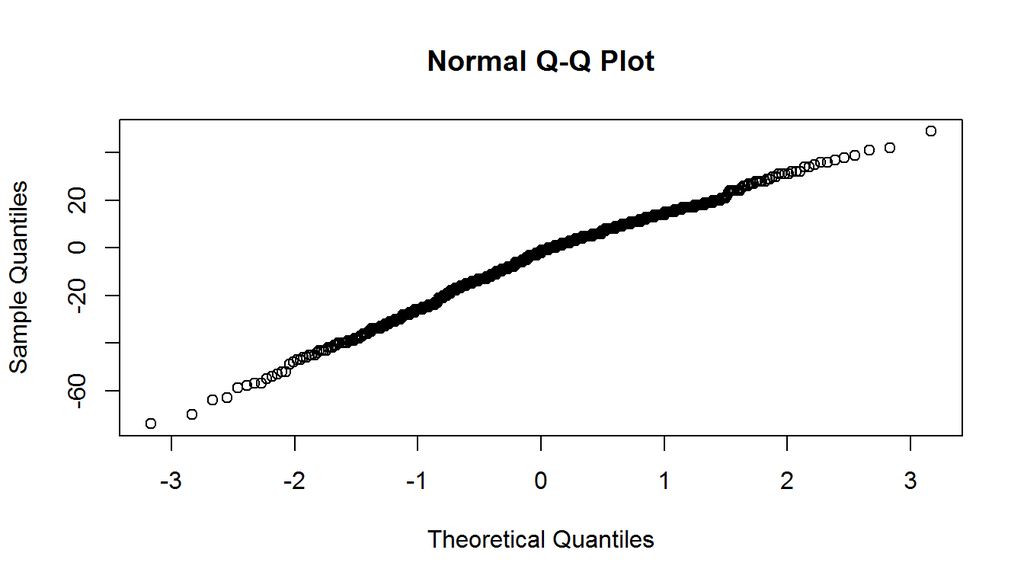

```r
movies <- movies %>% mutate(score_dif=critics_score-audience_score)
qqnorm(movies$score_dif)
```

```r
#We can tell from the plot that, there's only some minor skew. Since the samples are ramdomly selected, so we can say that the distribution of the difference in score is close to normal.
movies %>% summarise(mean(score_dif),sd(score_dif))
```

```
## # A tibble: 1 C 2
##   `mean(score_dif)` `sd(score_dif)`
##               <dbl>           <dbl>
## 1         -4.674347         20.1652
```

```r
pt((mean(movies$score_dif)-0)/(sd(movies$score_dif)/sqrt(651)),(651-1))
```

```
## [1] 2.692613e-09
```

```r
#Since the p-value is pretty small, so we can refuse the null hypothesis. The opinion of the critics and the audiences are different. We will try to figure out whether there's a connection between the score of critics and the audience in the next part.
```

## Part 4: Modeling

```r
#Let's filter some extreme value first.
movies_no_na <- movies %>% filter(!is.na(dvd_rel_month),runtime>70,runtime<180,studio!="GreyCat Films")

#And for the sake of making a better model, we can change two character variables into numeric variables.
movies_no_na$best_actress_win <- as.character(movies_no_na$best_actress_win)
movies_no_na$best_actress_win[movies_no_na$best_actress_win %in% c("yes")] <- 1
movies_no_na$best_actress_win[movies_no_na$best_actress_win %in% c("no")] <- 0
movies_no_na$best_actress_win <- as.numeric(movies_no_na$best_actress_win)

movies_no_na$best_actor_win <- as.character(movies_no_na$best_actor_win)
movies_no_na$best_actor_win[movies_no_na$best_actor_win %in% c("yes")] <- 1
movies_no_na$best_actor_win[movies_no_na$best_actor_win %in% c("no")] <- 0
movies_no_na$best_actor_win <- as.numeric(movies_no_na$best_actor_win)

#We are gonna create a variable, which indicates whether or not there's a actor or actress ever win an Oscar.
movies_no_na <- movies_no_na %>% mutate( best_actor_actress_win = best_actor_win + best_actress_win )

#Since we are focusing on predicting the audience score before a movie is made, for the purpose of helping people make a better decision on how to make a movie. Following variables will be used: title_type, genre, mpaa_rating, best_dir_win, runtime, dvd_rel_month, thtr_rel_month, best_actor_win, best_actress win,  studio, critics_score.
#Since it take too much pages to show step by step to choose which variable to use, we will jump to the final step to show the result.
m1 <- lm(audience_score ~  title_type+genre +mpaa_rating + best_dir_win +runtime  +dvd_rel_month + thtr_rel_month  + best_actor_actress_win + studio +critics_score, data = movies_no_na)
summary(m1)
```

```
##
## Call:
## lm(formula = audience_score ~ title_type + genre + mpaa_rating +
##     best_dir_win + runtime + dvd_rel_month + thtr_rel_month +
##     best_actor_actress_win + studio + critics_score, data = movies_no_na)
##
## Residuals:
##     Min      1Q  Median      3Q     Max
## -40.002  -6.136   0.000   5.667  35.000
##
## Coefficients:
##                                                 Estimate Std. Error
## (Intercept)                                     21.63667   11.00216
## title_typeFeature Film                           7.42941    7.76732
## title_typeTV Movie                              24.61336   14.16048
## genreAnimation                                   8.84730    6.59710
## genreArt House & International                   8.88072    6.10766
## genreComedy                                      0.33946    2.68229
## genreDocumentary                                24.62545    8.29288
## genreDrama                                       6.26352    2.44358
## genreHorror                                     -4.91348    4.54014
## genreMusical & Performing Arts                  19.43240    5.69433
## genreMystery & Suspense                         -3.00565    3.10840
## genreOther                                       5.45947    4.87888
## genreScience Fiction & Fantasy                  -3.80249    7.00273
## mpaa_ratingPG                                   -0.97721    4.85991
## mpaa_ratingPG-13                                -2.59929    5.11444
## mpaa_ratingR                                     0.64551    4.98393
## mpaa_ratingUnrated                              -1.62420    7.24907
## best_dir_winyes                                 -0.38708    2.69463
## runtime                                          0.06641    0.04926
## dvd_rel_month                                    0.15233    0.20518
## thtr_rel_month                                  -0.18308    0.20973
## best_actor_actress_win                          -2.09249    1.40498
## studio20th Century Fox Film Corporat             9.65219   10.83407
## studio20th Century Fox Film Corporation         -2.74962    7.42044
## studio7-57 Releasing                           -24.79657   15.60653
## studio7th art                                   -3.38103   15.84957
## studio905 Corporation                            1.86662   14.49975
## studioA24                                      -12.33877   14.61222
```

[output cut: 418 more lines]

```
## studioWarner Home Video                          0.471 0.638193
## studioWarner Independent                        -0.540 0.589559
## studioWarner Independent Pictures               -0.388 0.698063
## studioWarners Bros. Pictures                     0.329 0.742192
## studioWeinstein Company                         -1.593 0.111970
## studioWinstar                                   -0.191 0.848971
## studioYari Film Group Releasing                 -0.411 0.681014
## studioZeitgeist Films                           -0.365 0.715447
## critics_score                                   15.152  < 2e-16 ***
## ---
## Signif. codes:  0 '***' 0.001 '**' 0.01 '*' 0.05 '.' 0.1 ' ' 1
##
## Residual standard error: 13.92 on 398 degrees of freedom
## Multiple R-squared:  0.696,  Adjusted R-squared:  0.5234
## F-statistic: 4.032 on 226 and 398 DF,  p-value: < 2.2e-16
```

```r
anova(m1)
```

```
## Analysis of Variance Table
##
## Response: audience_score
##                         Df Sum Sq Mean Sq  F value    Pr(>F)
## title_type               2  23409   11705  60.3688 < 2.2e-16 ***
## genre                   10  27384    2738  14.1238 < 2.2e-16 ***
## mpaa_rating              4   3727     932   4.8062 0.0008519 ***
## best_dir_win             1   2468    2468  12.7308 0.0004035 ***
## runtime                  1   6333    6333  32.6640 2.151e-08 ***
## dvd_rel_month            1   1310    1310   6.7544 0.0096993 **
## thtr_rel_month           1     13      13   0.0688 0.7932448
## best_actor_actress_win   1    151     151   0.7789 0.3780005
## studio                 204  67359     330   1.7030 3.655e-06 ***
## critics_score            1  44515   44515 229.5933 < 2.2e-16 ***
## Residuals              398  77167     194
## ---
## Signif. codes:  0 '***' 0.001 '**' 0.01 '*' 0.05 '.' 0.1 ' ' 1
```

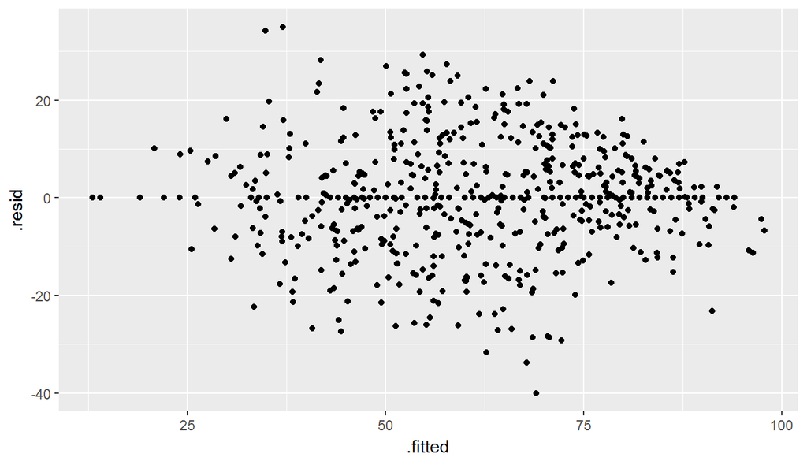

```r
ggplot(data = m1,aes(x=.fitted, y=.resid))+geom_point()
```

```r
#Since there's not any abvious linear relationship.

#We will transform three variables, which I learned from peer review. I'm pretty ambarrassed, because I don't know how to check the name of project. Sorry for that.

movies_no_na$runtime_convert<-cut(movies_no_na$runtime, c(0,90,120,150,999) ,labels = c('Short','Medium','Long', 'Very long'))
movies_no_na$thtr_rel_quarter_convert<-cut(movies_no_na$thtr_rel_month, c(0,3,6,9,12) ,labels = c('Q1','Q2','Q3','Q4'))
movies_no_na$dvd_rel_quarter_convert<-cut(movies_no_na$dvd_rel_month, c(0,3,6,9,12) ,labels = c('Q1','Q2','Q3','Q4'))


m_final <- lm(audience_score ~  title_type+genre +mpaa_rating + best_dir_win +runtime_convert +dvd_rel_quarter_convert + thtr_rel_quarter_convert + best_actor_actress_win + studio + critics_score, data = movies_no_na)
summary(m_final)
```

```
##
## Call:
## lm(formula = audience_score ~ title_type + genre + mpaa_rating +
##     best_dir_win + runtime_convert + dvd_rel_quarter_convert +
##     thtr_rel_quarter_convert + best_actor_actress_win + studio +
##     critics_score, data = movies_no_na)
##
## Residuals:
##     Min      1Q  Median      3Q     Max
## -39.649  -5.840   0.000   5.538  35.886
##
## Coefficients:
##                                                  Estimate Std. Error
## (Intercept)                                     30.217691  10.256641
## title_typeFeature Film                           8.748425   7.733479
## title_typeTV Movie                              25.676748  14.035762
## genreAnimation                                   6.734379   6.549486
## genreArt House & International                   9.193043   6.108958
## genreComedy                                     -0.451106   2.650636
## genreDocumentary                                23.890444   8.298174
## genreDrama                                       5.685242   2.452747
## genreHorror                                     -5.850052   4.479480
## genreMusical & Performing Arts                  18.821961   5.678415
## genreMystery & Suspense                         -3.045107   3.112121
## genreOther                                       4.594545   4.844167
## genreScience Fiction & Fantasy                  -6.525794   7.031896
## mpaa_ratingPG                                    1.566249   4.871367
## mpaa_ratingPG-13                                -0.108082   5.102868
## mpaa_ratingR                                     3.504375   5.008954
## mpaa_ratingUnrated                               2.264896   7.268182
## best_dir_winyes                                 -0.693291   2.673119
## runtime_convertMedium                           -3.687257   2.015614
## runtime_convertLong                              0.701912   2.721341
## runtime_convertVery long                         4.877524   5.127846
## dvd_rel_quarter_convertQ2                       -2.306516   1.969357
## dvd_rel_quarter_convertQ3                        1.933591   2.108203
## dvd_rel_quarter_convertQ4                        1.387076   2.006621
## thtr_rel_quarter_convertQ2                      -3.417129   2.092691
## thtr_rel_quarter_convertQ3                      -4.838770   2.203017
## thtr_rel_quarter_convertQ4                      -1.417323   2.042087
```

[output cut: 431 more lines]

```
## studioWarner Home Video                          0.243  0.80782
## studioWarner Independent                        -0.681  0.49654
## studioWarner Independent Pictures               -0.351  0.72568
## studioWarners Bros. Pictures                     0.429  0.66832
## studioWeinstein Company                         -1.506  0.13280
## studioWinstar                                   -0.174  0.86210
## studioYari Film Group Releasing                 -0.199  0.84215
## studioZeitgeist Films                           -0.637  0.52473
## critics_score                                   15.165  < 2e-16 ***
## ---
## Signif. codes:  0 '***' 0.001 '**' 0.01 '*' 0.05 '.' 0.1 ' ' 1
##
## Residual standard error: 13.77 on 392 degrees of freedom
## Multiple R-squared:  0.7072, Adjusted R-squared:  0.5339
## F-statistic: 4.081 on 232 and 392 DF,  p-value: < 2.2e-16
```

```r
anova(m_final)
```

```
## Analysis of Variance Table
##
## Response: audience_score
##                           Df Sum Sq Mean Sq  F value    Pr(>F)
## title_type                 2  23409   11705  61.7314 < 2.2e-16 ***
## genre                     10  27384    2738  14.4426 < 2.2e-16 ***
## mpaa_rating                4   3727     932   4.9147 0.0007082 ***
## best_dir_win               1   2468    2468  13.0182 0.0003484 ***
## runtime_convert            3   6405    2135  11.2595 4.222e-07 ***
## dvd_rel_quarter_convert    3   2583     861   4.5419 0.0038269 **
## thtr_rel_quarter_convert   3    274      91   0.4817 0.6952208
## best_actor_actress_win     1     81      81   0.4252 0.5147263
## studio                   204  69576     341   1.7988 3.987e-07 ***
## critics_score              1  43603   43603 229.9677 < 2.2e-16 ***
## Residuals                392  74326     190
## ---
## Signif. codes:  0 '***' 0.001 '**' 0.01 '*' 0.05 '.' 0.1 ' ' 1
```

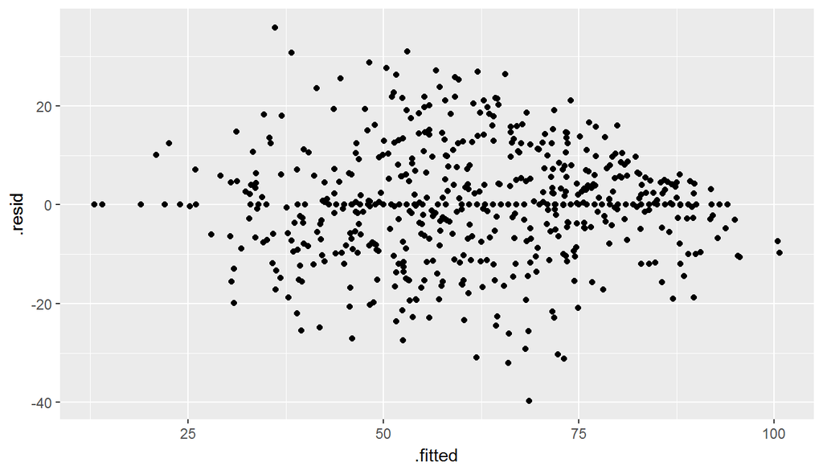

```r
#Now let's check the conditions again.
ggplot(data = m_final,aes(x=.fitted, y=.resid))+geom_point()
```

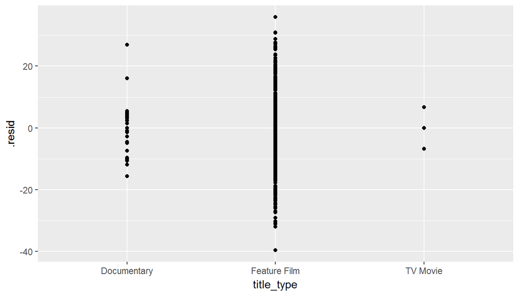

```r
ggplot(data = m_final,aes(x=title_type, y=.resid))+geom_point()
```

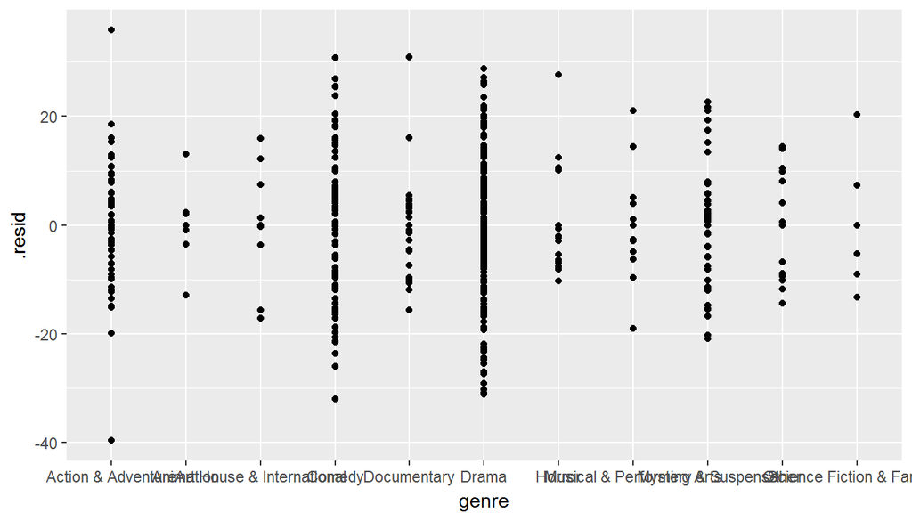

```r
ggplot(data = m_final,aes(x=genre, y=.resid))+geom_point()
```

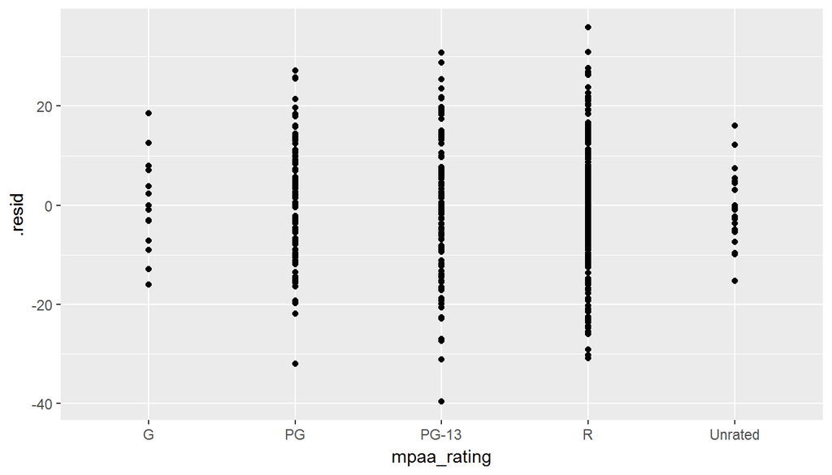

```r
ggplot(data = m_final,aes(x=mpaa_rating, y=.resid))+geom_point()
```

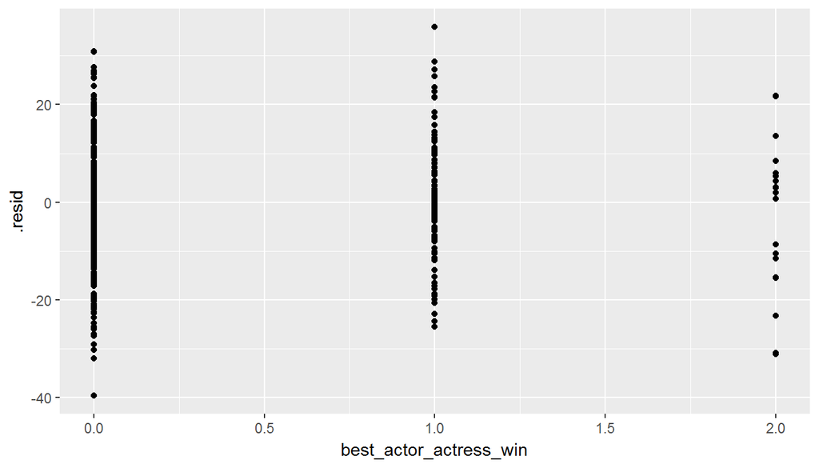

```r
ggplot(data = m_final,aes(x=best_actor_actress_win, y=.resid))+geom_point()
```

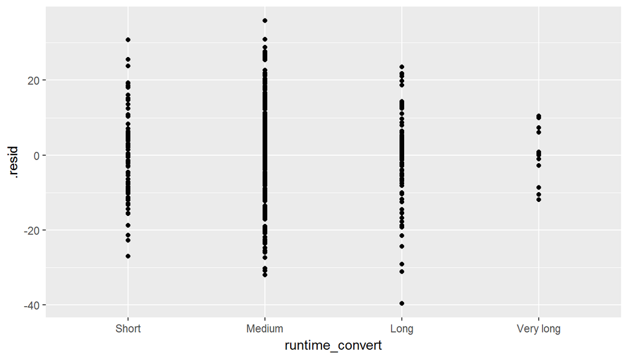

```r
ggplot(data = m_final,aes(x=runtime_convert, y=.resid))+geom_point()
```

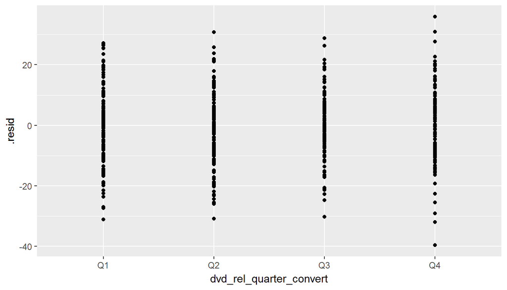

```r
ggplot(data = m_final,aes(x=dvd_rel_quarter_convert, y=.resid))+geom_point()
```

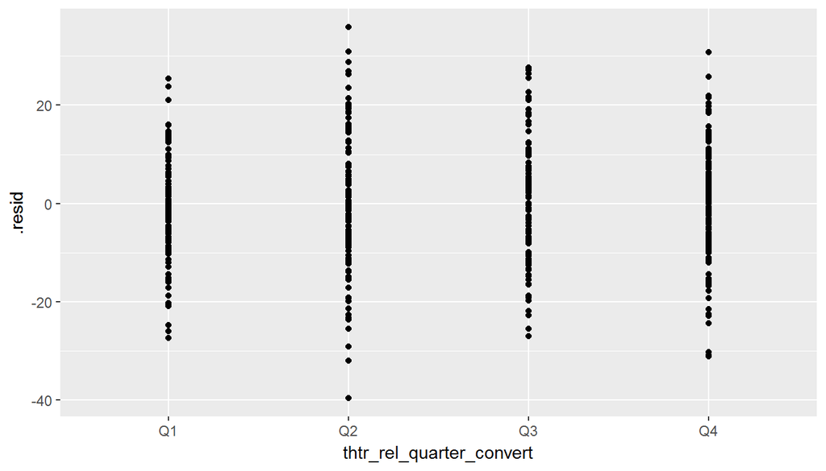

```r
ggplot(data = m_final,aes(x=thtr_rel_quarter_convert, y=.resid))+geom_point()
```

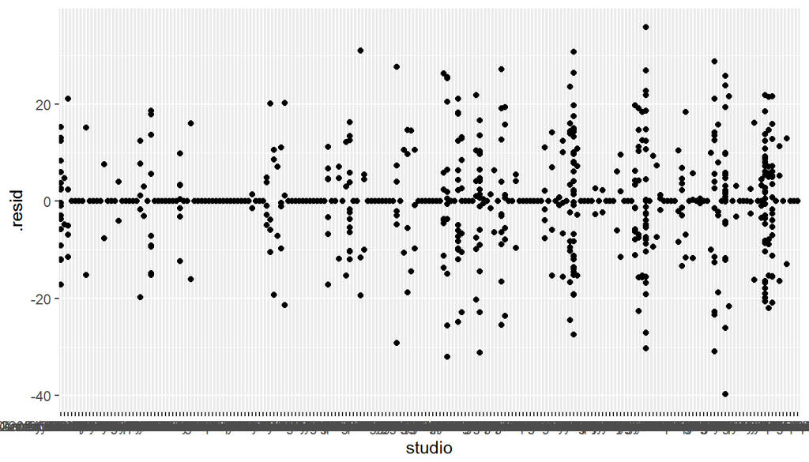

```r
ggplot(data = m_final,aes(x=studio, y=.resid))+geom_point()
```

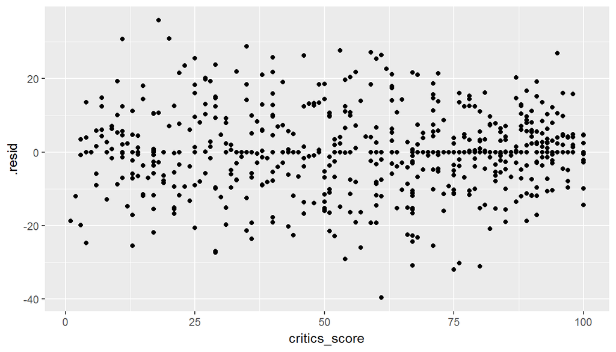

```r
ggplot(data = m_final,aes(x=critics_score, y=.resid))+geom_point()
```

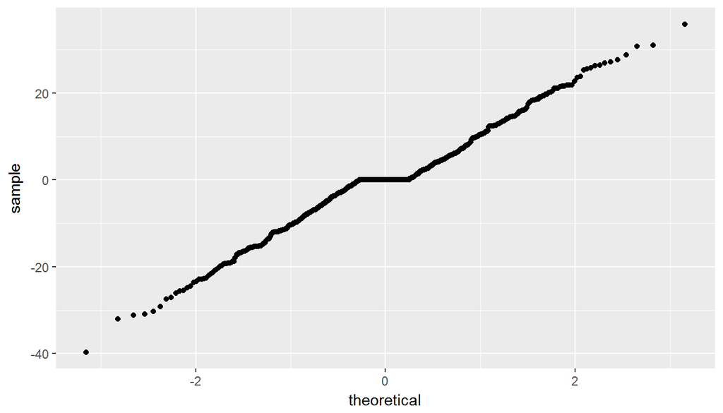

```r
ggplot(data = m_final,aes(sample=.resid))+stat_qq()
```

```r
#The conditions seem to fit for me.
```

## Part 5: Prediction

```r
#I have choosen the movie Zootopia and FURIOUS7. Here is the rottentomatoes link:
#Zootopia: https://www.rottentomatoes.com/m/zootopia
Zootopia <- data.frame(title_type= "Feature Film", mpaa_rating="PG",genre="Comedy" ,best_dir_win="yes", runtime_convert="Medium",dvd_rel_quarter_convert="Q2",studio="Walt Disney Pictures", thtr_rel_quarter_convert="Q3", best_actor_actress_win=0, critics_score=98)
predict(m_final, Zootopia)
```

```
##        1
## 72.16879
```

```r
predict(m_final, Zootopia, interval = "prediction", level = 0.95)
```

```
##        fit     lwr      upr
## 1 72.16879 39.4957 104.8419
```

```r
#The actual audience score is 92, so that is a bad prediction.

#FURIOUS7: https://www.rottentomatoes.com/m/furious_7
FURIOUS7 <- data.frame(title_type= "Feature Film", mpaa_rating="PG-13",genre="Mystery & Suspense" ,best_dir_win="no", runtime_convert="Long",dvd_rel_quarter_convert="Q3",studio="Universal Pictures", thtr_rel_quarter_convert="Q4", best_actor_actress_win=0, critics_score=79)
predict(m_final, FURIOUS7)
```

```
##        1
## 76.90231
```

```r
predict(m_final, FURIOUS7, interval = "prediction", level = 0.95)
```

```
##        fit      lwr      upr
## 1 76.90231 48.44591 105.3587
```

```r
#The actual audience score is 82, so that is a fair prediction.
```